# Model: yield_tha ~ surrounding landscape + intrinsic variaton + field design

# 1 Contents

# 2 Model Structure

*yield_tha ~ landscape heterogeneity (swf) + intrinsic variaton + field design*

This document analyses crop yield (`yield_tha`) in an agroforestry system as a function of three groups of predictors:

1. **surrounding landscape** - the proportion of small woody features (SWF) around the field, expressed as a *function* of distance from the field boundary (100-1000 m, 100 m steps);
2. **intrinsic variation** - the distance from the sampled plot to the tree strip within the field;
3. **field design** - fixed characteristics of each field/year (climate, soil, landscape configuration, crop, tree age, planting year).

Because the surrounding-landscape predictor is a curve rather than a single number, the response is modelled with a scalar-on-function regression (`refund::pfr`), which is a generalized additive model (`mgcv`) extended to accept functional covariates.

The data-exploration section below follows the structure recommended by Zuur et al. 2010: - outlier - distribution/homogeneity of the response - zero-inflation - collinearity - relationships - independence of observations.

```r
df <- read.csv("C:/Users/Elizaveta/OneDrive - Universität Bayreuth/Dokumente/MasterThesis/MA_RProject/data/AnalysisData/20260819_AFswf.csv")

df <- df |>
  mutate(year_AFplanting = case_when(
    field == "Dornburg"      ~ 2007,
    field == "Forst"         ~ 2010,
    field == "Gladbacherhof" ~ 2020,
    field == "IhingerHof"    ~ 2008,
    field == "Mariensee"     ~ 2008,
    field == "Reiffenhausen" ~ 2011,
    field == "Vechta"        ~ 2019,
    field == "Wendhausen"    ~ 2008
  ))

fert_raw <- gsub("[\u2013\u2212]", "-", df$fertilization_rate_kg_n_p_k_ha_1_year_1)
df$fert_N <- as.numeric(sub("^([0-9.]+).*", "\\1", fert_raw))
df$fert_N[fert_raw == "no fertilization"] <- 0

# one row per plot-year observation, for exploration of scalar variables
base_explore <- df |>
  distinct(id, field, year, yield_tha, distance_to_tree_strip,
           crop_unified, area, fert_N, temp_C_mean, sun_MJ_m2_mean,
           precip_mm_sum, l_shdi, l_contag, l_ed, l_ai,
           mean_slope, min_slope, max_slope, treeage,
           year_AFplanting, prop_swf_within)
```

# 3 Data Exploration

## 3.1 Distribution of the response variable: yield tha

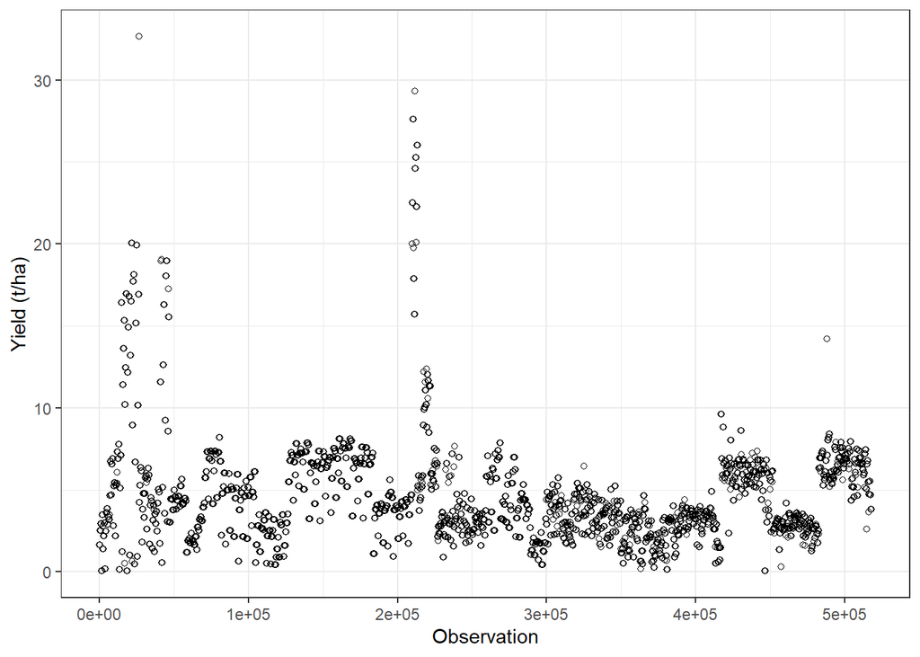

```r
ggplot(df, aes(x = seq_along(yield_tha), y = yield_tha)) +
  geom_point(shape = 1, alpha = 0.5) +
  theme_bw() +
  labs(
    x = "Observation",
    y = "Yield (t/ha)"
  )
```

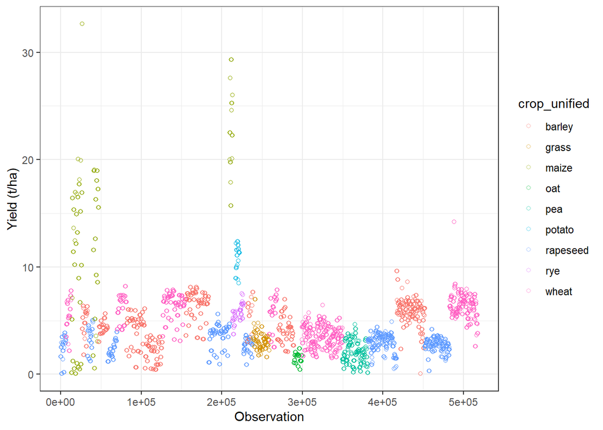

```r
ggplot(df, aes(x = seq_along(yield_tha), y = yield_tha, color = crop_unified)) +
  geom_point(shape = 1, alpha = 0.5) +
  theme_bw() +
  labs(
    x = "Observation",
    y = "Yield (t/ha)"
  )
```

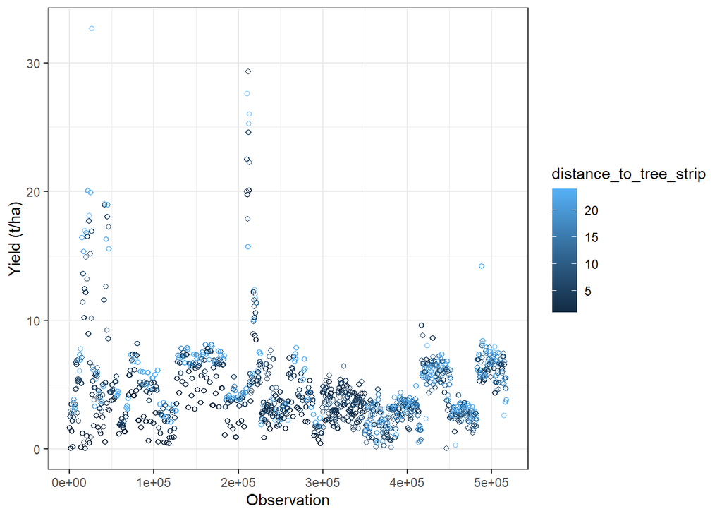

```r
ggplot(df, aes(x = seq_along(yield_tha), y = yield_tha, color = distance_to_tree_strip)) +
  geom_point(shape = 1, alpha = 0.5) +
  theme_bw() +
  labs(
    x = "Observation",
    y = "Yield (t/ha)"
  )
```

## 3.2 Outliers

Cleveland dotplots for every continuous variable (observation order on the y-axis, value on the x-axis) make isolated extreme values easy to spot without imposing a distributional assumption.

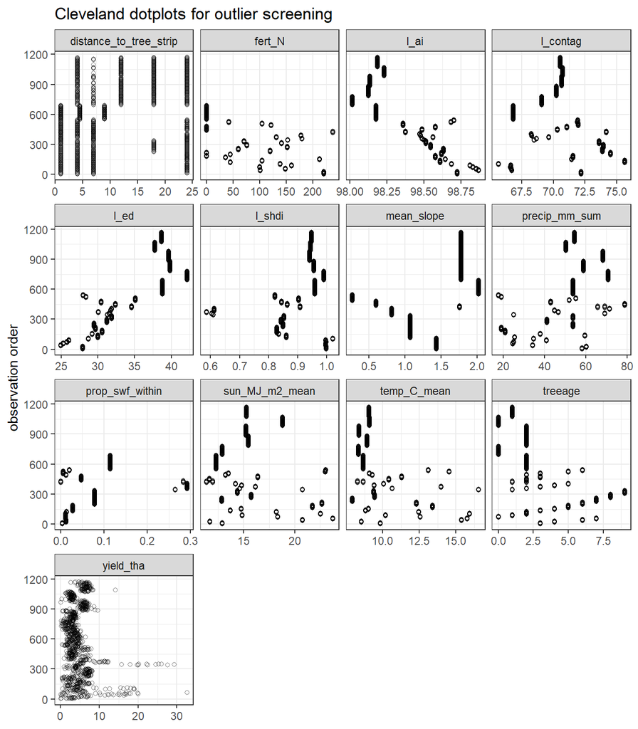

```r
num_vars <- c("yield_tha", "distance_to_tree_strip", "fert_N",
              "temp_C_mean", "sun_MJ_m2_mean", "precip_mm_sum",
              "l_shdi", "l_contag", "l_ed", "l_ai",
              "mean_slope", "treeage", "prop_swf_within")

dotplot_data <- base_explore |>
  select(all_of(num_vars)) |>
  mutate(row = row_number()) |>
  pivot_longer(-row, names_to = "variable", values_to = "value")

ggplot(dotplot_data, aes(x = value, y = row)) +
  geom_point(shape = 1, alpha = 0.5) +
  facet_wrap(~variable, scales = "free_x") +
  theme_bw() +
  labs(y = "observation order", x = NULL,
       title = "Cleveland dotplots for outlier screening")
```

Flag anything that sits noticeably apart from the bulk of the points in its panel; decide case by case whether it is a data-entry error (fix), a genuine extreme value (keep, but check its influence on the fitted model later), or an artefact of the extraction pipeline (e.g. a boundary raster cell with no woody-cover pixels).

## 3.3 Distribution / homogeneity of the response

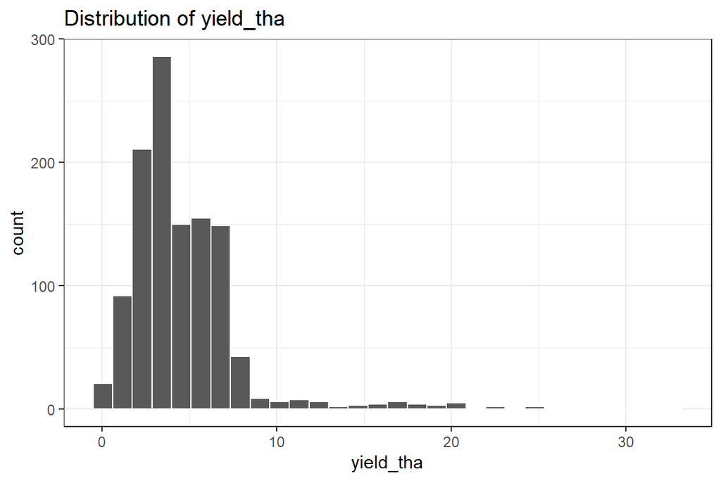

```r
ggplot(base_explore, aes(x = yield_tha)) +
  geom_histogram(bins = 30, colour = "white") +
  theme_bw() +
  labs(title = "Distribution of yield_tha")
```

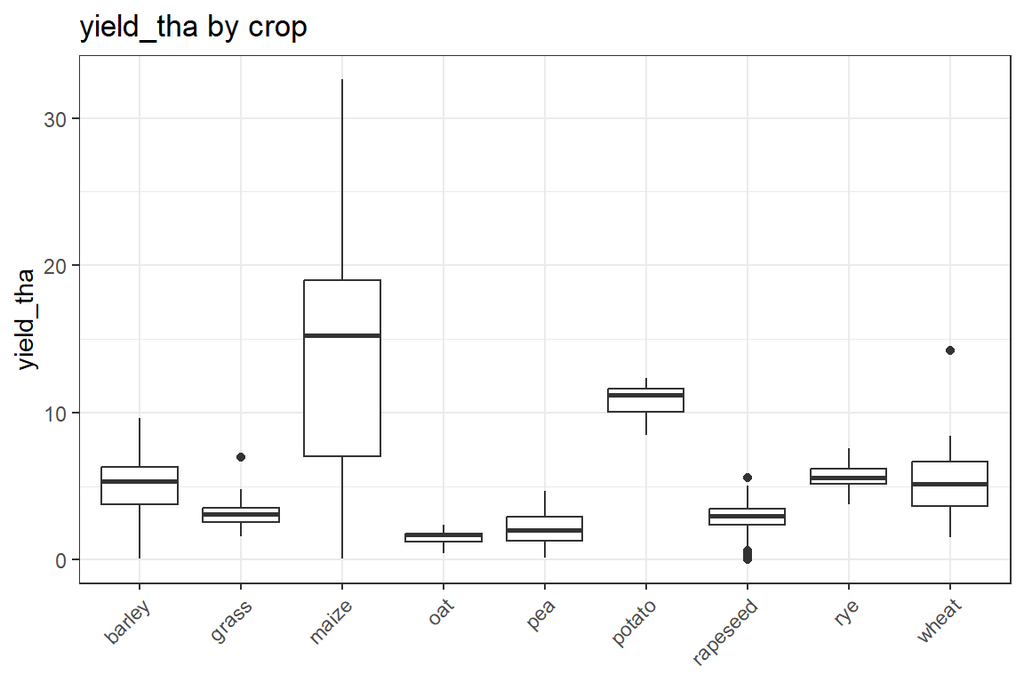

```r
ggplot(base_explore, aes(x = crop_unified, y = yield_tha)) +
  geom_boxplot() +
  theme_bw() +
  labs(title = "yield_tha by crop", x = NULL) +
  theme(axis.text.x = element_text(angle = 45, hjust = 1))
```

`yield_tha` differs strongly by crop (as the boxplot and the model’s parametric coefficients confirm), which is why `crop_unified` is kept as a fixed factor rather than pooled. Within-crop spread should look roughly comparable across fields/years for a Gaussian `pfr` to be an appropriate choice; strong heteroscedasticity by crop would motivate a `weights =` argument or a variance-modelling approach.

## 3.4 Zero-inflation

```r
sapply(base_explore[num_vars], function(x) mean(x == 0, na.rm = TRUE))
```

```
##              yield_tha distance_to_tree_strip                 fert_N
##             0.00000000             0.00000000             0.34621329
##            temp_C_mean         sun_MJ_m2_mean          precip_mm_sum
##             0.00000000             0.00000000             0.00000000
##                 l_shdi               l_contag                   l_ed
##             0.00000000             0.00000000             0.00000000
##                   l_ai             mean_slope                treeage
##             0.00000000             0.00000000             0.16567037
##        prop_swf_within
##             0.01736614
```

None of the continuous predictors or the response should show a disproportionate spike at zero (`fert_N` is expected to have a genuine, meaningful cluster at 0 for “no fertilization” plots - that is not zero-inflation in the statistical sense, just a real category, and is handled by the smooth term being able to flatten out near 0).

## 3.5 Collinearity among scalar predictors

```r
cor_mat <- base_explore |>
  select(all_of(num_vars[-1])) |>   # drop the response
  cor(use = "pairwise.complete.obs")

round(cor_mat, 2)
```

```
##                        distance_to_tree_strip fert_N temp_C_mean sun_MJ_m2_mean
## distance_to_tree_strip                   1.00   0.12       -0.09           0.07
## fert_N                                   0.12   1.00        0.07           0.02
## temp_C_mean                             -0.09   0.07        1.00           0.78
## sun_MJ_m2_mean                           0.07   0.02        0.78           1.00
## precip_mm_sum                            0.11   0.05       -0.75          -0.78
## l_shdi                                   0.06  -0.18       -0.32          -0.17
## l_contag                                 0.09   0.22       -0.11           0.11
## l_ed                                     0.15  -0.54       -0.67          -0.44
## l_ai                                    -0.15   0.53        0.66           0.44
## mean_slope                               0.06  -0.26       -0.49          -0.30
## treeage                                 -0.10   0.13        0.28           0.22
## prop_swf_within                         -0.04  -0.03       -0.12          -0.23
##                        precip_mm_sum l_shdi l_contag  l_ed  l_ai mean_slope
## distance_to_tree_strip          0.11   0.06     0.09  0.15 -0.15       0.06
## fert_N                          0.05  -0.18     0.22 -0.54  0.53      -0.26
## temp_C_mean                    -0.75  -0.32    -0.11 -0.67  0.66      -0.49
## sun_MJ_m2_mean                 -0.78  -0.17     0.11 -0.44  0.44      -0.30
## precip_mm_sum                   1.00   0.24    -0.11  0.65 -0.66       0.41
## l_shdi                          0.24   1.00    -0.27  0.42 -0.38       0.66
## l_contag                       -0.11  -0.27     1.00 -0.26  0.26      -0.44
## l_ed                            0.65   0.42    -0.26  1.00 -1.00       0.69
## l_ai                           -0.66  -0.38     0.26 -1.00  1.00      -0.68
## mean_slope                      0.41   0.66    -0.44  0.69 -0.68       1.00
## treeage                        -0.41  -0.41     0.44 -0.63  0.62      -0.53
## prop_swf_within                 0.32  -0.67    -0.23  0.33 -0.38       0.09
##                        treeage prop_swf_within
## distance_to_tree_strip   -0.10           -0.04
## fert_N                    0.13           -0.03
## temp_C_mean               0.28           -0.12
## sun_MJ_m2_mean            0.22           -0.23
## precip_mm_sum            -0.41            0.32
## l_shdi                   -0.41           -0.67
## l_contag                  0.44           -0.23
## l_ed                     -0.63            0.33
## l_ai                      0.62           -0.38
## mean_slope               -0.53            0.09
## treeage                   1.00           -0.11
## prop_swf_within          -0.11            1.00
```

## 3.6 Relationships between yield and candidate predictors

[figure not shown]

```r
rel_data <- base_explore |>
  select(yield_tha, distance_to_tree_strip, fert_N, temp_C_mean,
         precip_mm_sum, l_shdi, treeage, crop_unified) |>
  pivot_longer(-c(yield_tha, crop_unified), names_to = "variable", values_to = "value")

ggplot(rel_data, aes(x = value, y = yield_tha)) +
  geom_point(alpha = 0.3) +
  geom_smooth(method = "loess", se = FALSE) +
  facet_wrap(~ crop_unified + variable, scales = "free") +
  theme_bw()
```

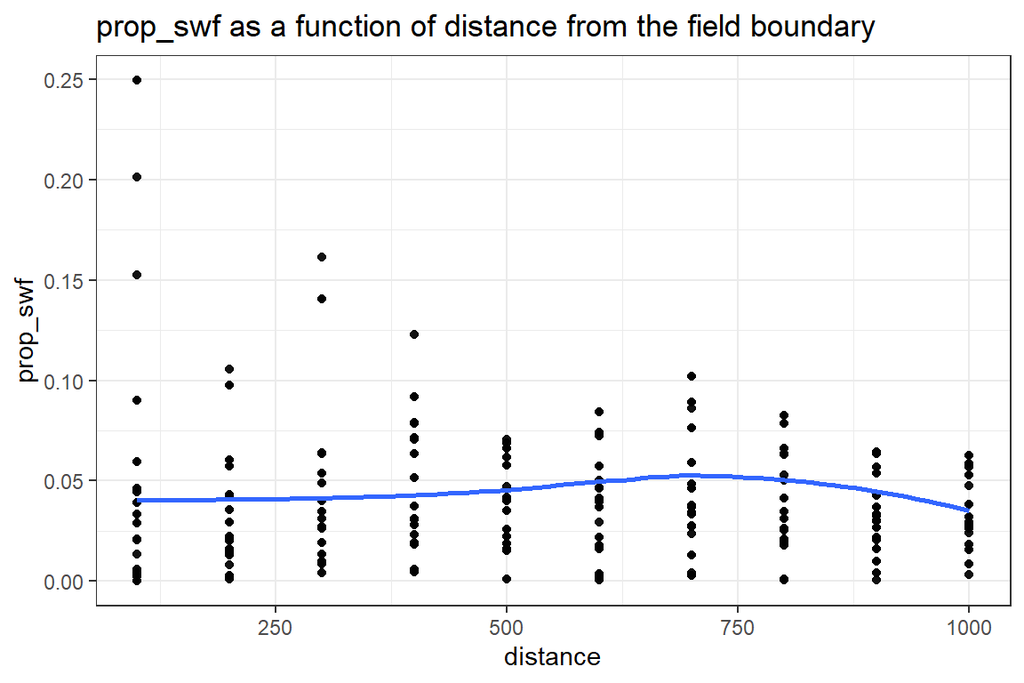

```r
df |>
  select(id, distance, prop_swf) |>
  distinct() |>
  ggplot(aes(x = distance, y = prop_swf)) +
  geom_point(alpha = 0.2) +
  geom_smooth(method = "loess", se = FALSE) +
  theme_bw() +
  labs(title = "prop_swf as a function of distance from the field boundary")
```

## 3.7 Independence of observations

```r
table(base_explore$field)
```

```
##
##      Dornburg         Forst Gladbacherhof    IhingerHof     Mariensee
##           226            64           144           480            48
## Reiffenhausen        Vechta    Wendhausen
##            24            73           112
```

```r
base_explore |> count(field, year) |> tidyr::pivot_wider(names_from = year, values_from = n)
```

```
## # A tibble: 8 × 9
##   field         `2016` `2017` `2018` `2019` `2020` `2021` `2022` `2023`
##   <chr>          <int>  <int>  <int>  <int>  <int>  <int>  <int>  <int>
## 1 Dornburg          16     16     16     32     30     40     40     36
## 2 Forst             16     16     NA     16     16     NA     NA     NA
## 3 Gladbacherhof     NA     NA     NA     NA     NA    144     NA     NA
## 4 IhingerHof        90     NA    102     NA     NA    100     88    100
## 5 Mariensee         NA     24     24     NA     NA     NA     NA     NA
## 6 Reiffenhausen     12     12     NA     NA     NA     NA     NA     NA
## 7 Vechta            NA     NA     NA     12     13     16     16     16
## 8 Wendhausen        16     16     NA     16     16     16     16     16
```

# 4 Variable Overview

[output not shown]

# 5 Model Specification

## 5.1 Building the functional covariate

`prop_swf` is recorded at 10 fixed distances (100-1000 m, 100 m steps) per `id`. Pivoting to wide format gives one row per `id` and one column per distance - this matrix is the discretised functional predictor `W_swf(distance)`, and `grid` is its domain.

```r
W_swf <- df |>
  dplyr::select(id, distance, swf_year, prop_swf) |>
  unique() |>
  pivot_wider(names_from = distance, values_from = prop_swf) |>
  arrange(id)

id_order <- W_swf$id
W_mat    <- as.matrix(W_swf[, -c(1, 2)])
grid     <- as.numeric(colnames(W_mat))

stopifnot(!anyNA(grid), length(grid) == ncol(W_mat))
```

## 5.2 Building the scalar dataset

One row per `id`, aligned exactly to the row order of `W_mat`.

```r
base <- df |>
  distinct(id, field, year, yield_tha, distance_to_tree_strip,
           crop_unified, area, fert_N, temp_C_mean, sun_MJ_m2_mean,
           precip_mm_sum, l_shdi, l_contag, l_ed, l_ai,
           mean_slope, min_slope, max_slope, treeage,
           year_AFplanting, prop_swf_within) |>
  filter(id %in% id_order) |>
  slice(match(id_order, id))

stopifnot(nrow(base) == nrow(W_mat))
base$W_swf <- W_mat

base$field         <- factor(base$field)
base$crop_unified  <- factor(base$crop_unified)
```

## 5.3 Adaptive basis dimensions

`safe_k()` caps every smooth’s basis dimension (`k`) at `(number of unique values - 1)` of its own covariate, so that `smooth.construct` can never fail regardless of how listwise deletion (NAs anywhere in the formula) thins the fitting sample.

```r
safe_k <- function(x, k_wanted) {
  min(k_wanted, length(unique(x[!is.na(x)])) - 1)
}

k_dist  <- safe_k(base$distance_to_tree_strip, 6)
k_fertN <- safe_k(base$fert_N,                 5)
k_temp  <- safe_k(base$temp_C_mean,            5)
k_sun   <- safe_k(base$sun_MJ_m2_mean,         5)
k_prec  <- safe_k(base$precip_mm_sum,          5)
k_shdi  <- safe_k(base$l_shdi,                 5)
k_cont  <- safe_k(base$l_contag,               5)
k_ed    <- safe_k(base$l_ed,                   5)
k_ai    <- safe_k(base$l_ai,                   5)
k_tree  <- safe_k(base$treeage,                5)
```

## 5.4 The model

```r
model <- pfr(
  yield_tha ~
    lf(W_swf, argvals = grid, bs = "ps", k = 15) +      # (1) surrounding landscape
    s(distance_to_tree_strip, bs = "tp", k = k_dist) +   # (2) intrinsic variation
    s(fert_N,         bs = "tp", k = k_fertN) +    # thin plate regression splines
    s(temp_C_mean,    bs = "tp", k = k_temp) +
    s(sun_MJ_m2_mean, bs = "tp", k = k_sun) +
    s(precip_mm_sum,  bs = "tp", k = k_prec) +
    s(l_shdi,         bs = "tp", k = k_shdi) +
    s(l_contag,       bs = "tp", k = k_cont) +
    s(l_ed,           bs = "tp", k = k_ed) +
    s(l_ai,           bs = "tp", k = k_ai) +
    s(treeage,        bs = "tp", k = k_tree) +
    crop_unified +
    s(field, bs = "re"), # random effects
  data   = base,
  method = "REML"
)

summary(model)
```

```
##
## Family: gaussian
## Link function: identity
##
## Formula:
## yield_tha ~ s(x = W_swf.tmat, by = L.W_swf, bs = "ps", k = 15) +
##     s(distance_to_tree_strip, bs = "tp", k = k_dist) + s(fert_N,
##     bs = "tp", k = k_fertN) + s(temp_C_mean, bs = "tp", k = k_temp) +
##     s(sun_MJ_m2_mean, bs = "tp", k = k_sun) + s(precip_mm_sum,
##     bs = "tp", k = k_prec) + s(l_shdi, bs = "tp", k = k_shdi) +
##     s(l_contag, bs = "tp", k = k_cont) + s(l_ed, bs = "tp", k = k_ed) +
##     s(l_ai, bs = "tp", k = k_ai) + s(treeage, bs = "tp", k = k_tree) +
##     crop_unified + s(field, bs = "re")
##
## Parametric coefficients:
##                      Estimate Std. Error t value Pr(>|t|)
## (Intercept)            3.1221     0.6466   4.829 1.73e-06 ***
## crop_unifiedgrass     -0.9981     1.1039  -0.904    0.366
## crop_unifiedmaize      7.5229     0.8961   8.395 3.14e-16 ***
## crop_unifiedpotato    -6.1568     1.4362  -4.287 2.10e-05 ***
## crop_unifiedrapeseed  -2.7075     0.4246  -6.377 3.53e-10 ***
## crop_unifiedrye       -7.3093     1.4037  -5.207 2.61e-07 ***
## crop_unifiedwheat      0.3732     0.5532   0.675    0.500
## ---
## Signif. codes:  0 '***' 0.001 '**' 0.01 '*' 0.05 '.' 0.1 ' ' 1
##
## Approximate significance of smooth terms:
##                                 edf Ref.df      F  p-value
## s(W_swf.tmat):L.W_swf     3.3585585  3.717  8.095 3.92e-06 ***
## s(distance_to_tree_strip) 4.7644208  4.961 43.661  < 2e-16 ***
## s(fert_N)                 1.0001949  1.000  8.217  0.00429 **
## s(temp_C_mean)            1.0000964  1.000 17.328 3.65e-05 ***
## s(sun_MJ_m2_mean)         1.0000856  1.000 39.302  < 2e-16 ***
## s(precip_mm_sum)          1.0001610  1.000 15.788 7.95e-05 ***
## s(l_shdi)                 1.0000317  1.000  0.057  0.81175
## s(l_contag)               1.4539834  1.720  4.268  0.02601 *
## s(l_ed)                   1.0000244  1.000  2.133  0.14463
## s(l_ai)                   1.0000288  1.000  2.173  0.14093
## s(treeage)                1.0001624  1.000  7.715  0.00564 **
## s(field)                  0.0000981  5.000  0.000  0.64990
## ---
## Signif. codes:  0 '***' 0.001 '**' 0.01 '*' 0.05 '.' 0.1 ' ' 1
##
## R-sq.(adj) =  0.753   Deviance explained = 76.2%
## -REML =   1389  Scale est. = 4.1385    n = 647
```

Term-by-term rationale:

- `lf(W_swf, argvals = grid, bs = "ps", k = 15)` - the surrounding landscape term. Estimates a smooth coefficient function beta(distance) over the 100-1000 m domain using a penalized B-spline (`bs = "ps"`) basis; `k = 15` is generous relative to the 10 observed distances but is fine because the roughness penalty (chosen by REML) controls the effective wiggliness, not `k` itself.
- `s(distance_to_tree_strip, bs = "tp", k = k_dist)` - intrinsic variation. A thin-plate smooth lets yield respond nonlinearly to proximity to the tree strip, consistent with the competition-zone literature (Swieter et al. 2019). I THINK HERE ONE CAN JUST TAKE A LOG SMOOTH THERE IS NO INDICATION THAT THESE EFFECTS ARE NON LINEAR SO I WOULD TAKE THEM LINEARLY The block of `s(..., bs = "tp", k = ...)` terms for `fert_N`, climate normals, and landscape-configuration indices represents field design as smooth (not necessarily linear) scalar effects.
- `crop_unified` - parametric factor; crop identity has a large, roughly additive effect on yield and does not need smoothing.
- `s(field, bs = "re")` - random intercept for field, absorbing unmodelled, field-specific variation and acknowledging that observations within a field are not independent.

# 6 Model Validation and Verification

## 6.1 Basis dimension check (k-index)

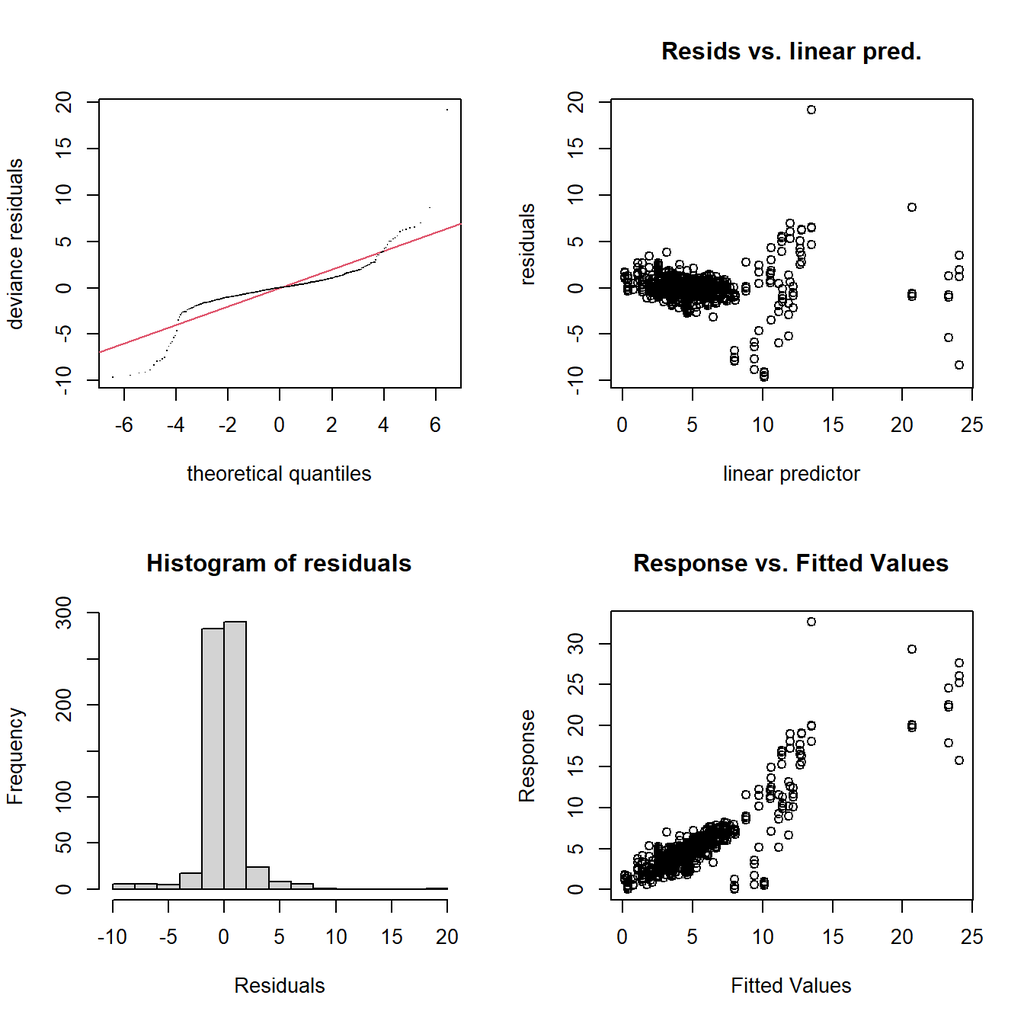

```
##
## Method: REML   Optimizer: outer newton
## full convergence after 9 iterations.
## Gradient range [-8.74097e-05,0.0001251803]
## (score 1388.978 & scale 4.138479).
## Hessian positive definite, eigenvalue range [3.409955e-06,314.0128].
## Model rank =  70 / 70
##
## Basis dimension (k) checking results. Low p-value (k-index<1) may
## indicate that k is too low, especially if edf is close to k'.
##
##                                 k'      edf k-index p-value
## s(W_swf.tmat):L.W_swf     1.50e+01 3.36e+00      NA      NA
## s(distance_to_tree_strip) 5.00e+00 4.76e+00    0.66  <2e-16 ***
## s(fert_N)                 4.00e+00 1.00e+00    1.38       1
## s(temp_C_mean)            4.00e+00 1.00e+00    1.42       1
## s(sun_MJ_m2_mean)         4.00e+00 1.00e+00    1.39       1
## s(precip_mm_sum)          4.00e+00 1.00e+00    1.41       1
## s(l_shdi)                 4.00e+00 1.00e+00    1.40       1
## s(l_contag)               4.00e+00 1.45e+00    1.40       1
## s(l_ed)                   4.00e+00 1.00e+00    1.39       1
## s(l_ai)                   4.00e+00 1.00e+00    1.40       1
## s(treeage)                4.00e+00 1.00e+00    1.39       1
## s(field)                  7.00e+00 9.81e-05      NA      NA
## ---
## Signif. codes:  0 '***' 0.001 '**' 0.01 '*' 0.05 '.' 0.1 ' ' 1
```

```r
gam.check(model)
```

Look at the `k-index` column: a value well below 1 together with a low p-value for a given smooth means `k` may be too small (the smooth is being forced to be smoother than the data support) and should be increased (subject to `safe_k`’s ceiling); values around/above 1 are fine.

## 6.2 Residual diagnostics

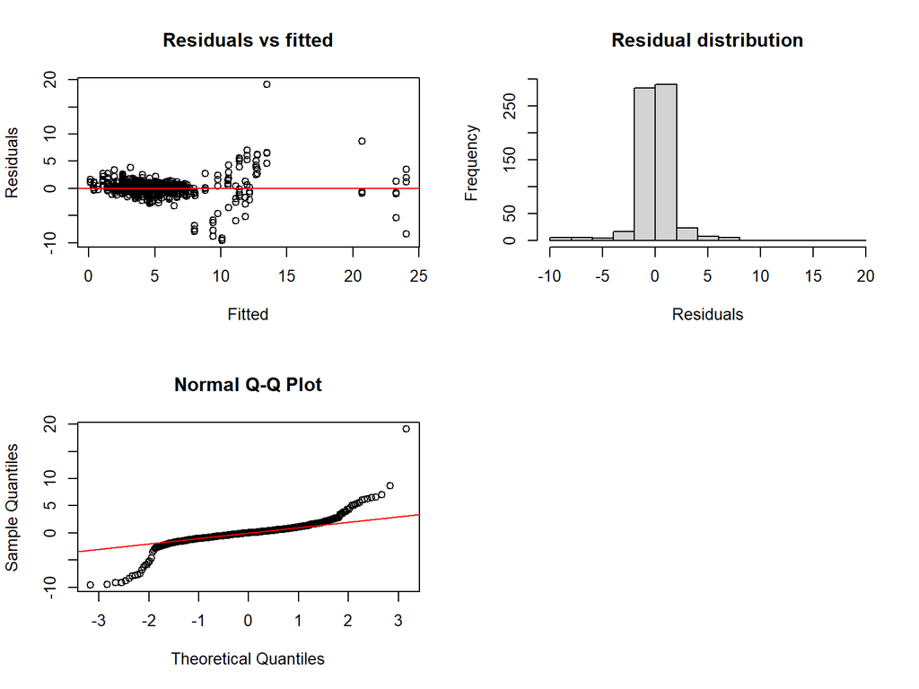

```r
res <- residuals(model)
fit <- fitted(model)

par(mfrow = c(2, 2))
plot(fit, res, main = "Residuals vs fitted", xlab = "Fitted", ylab = "Residuals")
abline(h = 0, col = "red")
hist(res, main = "Residual distribution", xlab = "Residuals")
qqnorm(res); qqline(res, col = "red")
# plot(base$distance_to_tree_strip, res,
#      main = "Residuals vs distance_to_tree_strip",
#      xlab = "distance_to_tree_strip", ylab = "Residuals")
# abline(h = 0, col = "red")
# par(mfrow = c(1, 1))
```

## 6.3 Residuals by field and by year (checks the random-effect structure)

```r
# resid_df <- base |> mutate(resid = res)
#
# ggplot(resid_df, aes(x = field, y = resid)) +
#   geom_boxplot() +
#   geom_hline(yintercept = 0, colour = "red") +
#   theme_bw() +
#   labs(title = "Residuals by field") +
#   theme(axis.text.x = element_text(angle = 45, hjust = 1))
#
# ggplot(resid_df, aes(x = factor(year), y = resid)) +
#   geom_boxplot() +
#   geom_hline(yintercept = 0, colour = "red") +
#   theme_bw() +
#   labs(title = "Residuals by year", x = "year")
```

If residuals still show a systematic offset by field, `s(field, bs = "re")` is not fully doing its job (often because of the concurvity issue described next) and the fixed effects should be simplified. A systematic pattern by year suggests adding a year term.

## 6.4 Concurvity (the GAM analogue of collinearity)

```r
concurvity(model, full = TRUE)
```

```
##          para s(W_swf.tmat):L.W_swf s(distance_to_tree_strip) s(fert_N)
## worst       1              1.657028                 0.6670435 0.9999665
## observed    1              1.000000                 0.2200983 0.9817320
## estimate    1              1.000000                 0.2773713 0.9773575
##          s(temp_C_mean) s(sun_MJ_m2_mean) s(precip_mm_sum) s(l_shdi)
## worst                 1                 1                1         1
## observed              1                 1                1         1
## estimate              1                 1                1         1
##          s(l_contag) s(l_ed) s(l_ai) s(treeage) s(field)
## worst              1       1       1          1        1
## observed           1       1       1          1        1
## estimate           1       1       1          1        1
```

```r
concurvity(model, full = FALSE)
```

```
## $worst
##                                   para s(W_swf.tmat):L.W_swf
## para                      1.000000e+00             1.0434325
## s(W_swf.tmat):L.W_swf     9.817007e-01             1.0000000
## s(distance_to_tree_strip) 1.249384e-26             0.3423536
## s(fert_N)                 1.338467e-27             0.8062634
## s(temp_C_mean)            2.947100e-28             0.7327402
## s(sun_MJ_m2_mean)         7.353488e-21             0.7437522
## s(precip_mm_sum)          6.972366e-29             0.7254047
## s(l_shdi)                 9.832835e-23             1.0230518
## s(l_contag)               2.232055e-27             0.9681880
## s(l_ed)                   3.147659e-24             0.9903616
## s(l_ai)                   6.117100e-25             1.0037526
## s(treeage)                4.675251e-29             0.8272882
## s(field)                  1.000000e+00             1.0485140
##                           s(distance_to_tree_strip)    s(fert_N) s(temp_C_mean)
## para                                   1.224622e-26 1.243533e-27   3.458178e-28
## s(W_swf.tmat):L.W_swf                  3.514752e-01 8.183818e-01   7.271882e-01
## s(distance_to_tree_strip)              1.000000e+00 1.969376e-01   1.234714e-01
## s(fert_N)                              1.969376e-01 1.000000e+00   3.182564e-01
## s(temp_C_mean)                         1.234714e-01 3.182564e-01   1.000000e+00
## s(sun_MJ_m2_mean)                      1.357933e-01 5.674386e-01   8.985095e-01
## s(precip_mm_sum)                       1.204051e-01 4.310372e-01   7.730715e-01
## s(l_shdi)                              2.502763e-01 4.884555e-01   4.547754e-01
## s(l_contag)                            1.653168e-01 4.024278e-01   2.636433e-01
## s(l_ed)                                3.344197e-01 5.921012e-01   3.971785e-01
## s(l_ai)                                3.345893e-01 6.058037e-01   4.051640e-01
## s(treeage)                             1.741403e-01 3.372117e-01   4.717405e-01
## s(field)                               3.361616e-01 8.094754e-01   4.845386e-01
##                           s(sun_MJ_m2_mean) s(precip_mm_sum)    s(l_shdi)
## para                           7.353584e-21     8.816486e-29 9.847640e-23
## s(W_swf.tmat):L.W_swf          7.413579e-01     7.517998e-01 9.948541e-01
## s(distance_to_tree_strip)      1.357933e-01     1.204051e-01 2.502763e-01
## s(fert_N)                      5.674386e-01     4.310372e-01 4.884555e-01
## s(temp_C_mean)                 8.985095e-01     7.730715e-01 4.547754e-01
## s(sun_MJ_m2_mean)              1.000000e+00     9.177253e-01 5.937717e-01
## s(precip_mm_sum)               9.177253e-01     1.000000e+00 5.154396e-01
## s(l_shdi)                      5.937717e-01     5.154396e-01 1.000000e+00
## s(l_contag)                    1.353690e-01     2.415534e-01 7.829185e-01
## s(l_ed)                        5.462826e-01     5.118188e-01 9.410663e-01
```

[output cut: 160 more lines]

```
## s(field)                  7.981206e-01 8.960496e-01 9.041746e-01 5.003946e-01
##                             s(field)
## para                      0.22062832
## s(W_swf.tmat):L.W_swf     0.97938631
## s(distance_to_tree_strip) 0.09150194
## s(fert_N)                 0.23497267
## s(temp_C_mean)            0.14219248
## s(sun_MJ_m2_mean)         0.15849545
## s(precip_mm_sum)          0.17462659
## s(l_shdi)                 0.49082562
## s(l_contag)               0.35542442
## s(l_ed)                   0.44212201
## s(l_ai)                   0.46351549
## s(treeage)                0.21218791
## s(field)                  1.00000000
```

## 6.5 Influence / leave-one-field-out sensitivity

```r
# refit dropping each field once, compare beta(distance) for W_swf
fields <- levels(base$field)
loo_coefs <- lapply(fields, function(f) {
  m <- update(model, data = base[base$field != f, ])
  coef(m, n = length(grid))
})
```

With only 8 fields, a leave-one-field-out refit is cheap and directly answers “is the estimated surrounding-landscape effect (or the distance-to-tree-strip effect) driven by a single field?” - important given the concurvity concerns above. Compare the estimated beta(distance) curve (and its confidence band) across the 8 refits, e.g. by overlaying `coef(m, n = ...)` for each fold.

## 6.6 Reported fit statistics

```r
summary(model)$r.sq
```

```
## [1] 0.7532343
```

```r
summary(model)$dev.expl
```

```
## [1] 0.7622408
```

```r
AIC(model)
```

```
## [1] 2782.801
```

Report adjusted R^2, deviance explained, and REML/AIC alongside the diagnostics above - a high R^2 (as in the current model, ~0.76) is not by itself evidence that the model is correctly specified if concurvity is high; the diagnostics in this section are what establishes that.

```r
library(dplyr)
library(tidyr)
library(FactoMineR)
library(factoextra)
library(ggplot2)

W_swf <- df |>
  dplyr::select(id, distance, prop_swf) |>
  unique() |>
  filter(distance %in% c(100, 500, 1000)) |>
  pivot_wider(names_from = distance, values_from = prop_swf, names_prefix = "swf_") |>
  arrange(id)

pca_data <- df |>
  distinct(id, yield_tha, distance_to_tree_strip, crop_unified) |>
  inner_join(W_swf, by = "id") |>
  na.omit()

pca_res <- PCA(pca_data |> select(-id),
                quali.sup = which(names(pca_data |> select(-id)) == "crop_unified"),
                quanti.sup = which(names(pca_data |> select(-id)) == "yield_tha"),
                graph = FALSE)

get_eigenvalue(pca_res)
```

```
##       eigenvalue variance.percent cumulative.variance.percent
## Dim.1  1.6501266        41.253165                    41.25316
## Dim.2  1.1731086        29.327716                    70.58088
## Dim.3  0.8335961        20.839901                    91.42078
## Dim.4  0.3431687         8.579218                   100.00000
```

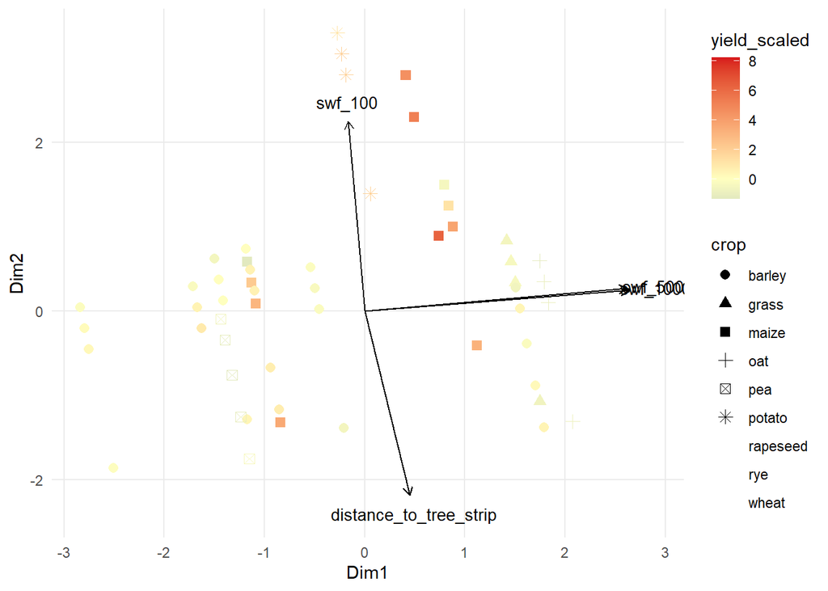

```r
ind_coord <- as.data.frame(pca_res$ind$coord[, 1:2])
colnames(ind_coord) <- c("Dim1", "Dim2")
ind_coord$yield_scaled <- as.numeric(scale(pca_data$yield_tha))
ind_coord$crop_unified <- pca_data$crop_unified

var_coord <- as.data.frame(pca_res$var$coord[, 1:2])
colnames(var_coord) <- c("Dim1", "Dim2")
var_coord$label <- rownames(var_coord)

scale_f <- 0.8 * max(abs(ind_coord[, 1:2])) / max(abs(var_coord[, 1:2]))

ggplot() +
  geom_point(data = ind_coord,
             aes(x = Dim1, y = Dim2, color = yield_scaled, shape = crop_unified),
             size = 2.5) +
  geom_segment(data = var_coord,
               aes(x = 0, y = 0, xend = Dim1 * scale_f, yend = Dim2 * scale_f),
               arrow = arrow(length = unit(0.2, "cm")), color = "black") +
  geom_text(data = var_coord,
            aes(x = Dim1 * scale_f * 1.1, y = Dim2 * scale_f * 1.1, label = label),
            size = 3.5) +
  scale_color_gradient2(low = "#2c7fb8", mid = "#ffffbf", high = "#d7191c",
                         midpoint = 0) +
  theme_minimal() +
  labs(x = "Dim1", y = "Dim2", color = "yield_scaled", shape = "crop") +
  theme(panel.grid.minor = element_blank())
```

```r
swf_long <- df |>
  dplyr::select(id, field, distance, prop_swf) |>
  unique()

swf_wide <- swf_long |>
  tidyr::pivot_wider(names_from = distance, values_from = prop_swf) |>
  arrange(id)

grid <- as.numeric(names(swf_wide)[-c(1, 2)])
Y_swf <- as.matrix(swf_wide[, -c(1, 2)])
field_id <- df |> distinct(id, field) |> arrange(id) |> pull(field)

swf_model <- pffr(
  Y_swf ~ s(field_id, bs = "re"),
  yind = grid,
  data = list(Y_swf = Y_swf, field_id = factor(field_id)),
  family = binomial()
)

summary(swf_model)
```

```
##
## Family: binomial
## Link function: logit
##
## Formula:
## Y_swf ~ s(field_id, bs = "re")
##
## Constant coefficients:
##             Estimate Std. Error z value Pr(>|z|)
## (Intercept)  -3.1107     0.1226  -25.36   <2e-16 ***
## ---
## Signif. codes:  0 '***' 0.001 '**' 0.01 '*' 0.05 '.' 0.1 ' ' 1
##
## Smooth terms & functional coefficients:
##                          edf Ref.df Chi.sq p-value
## Intercept(yindex)  9.312e-04      9    0.0  <2e-16 ***
## s(field_id,yindex) 1.814e+01     18  123.6  <2e-16 ***
## ---
## Signif. codes:  0 '***' 0.001 '**' 0.01 '*' 0.05 '.' 0.1 ' ' 1
##
## R-sq.(adj) =  0.564   Deviance explained = 52.6%
## -REML score = 630.95  Scale est. = 1         n = 11710 (1171 x 10)
## Sandwich correction (cluster) applied to covariance matrices.
```

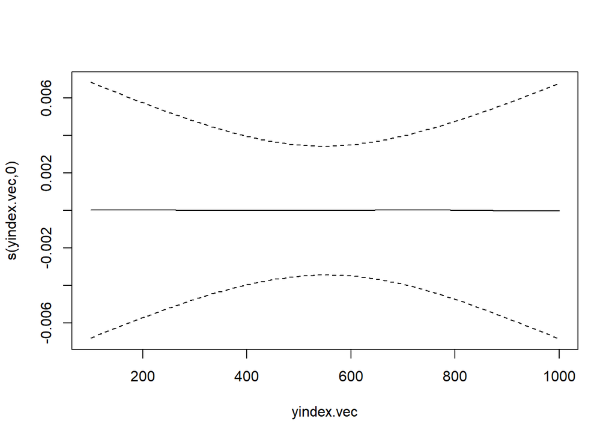

```r
plot(swf_model)
```

```r
fitted_swf <- fitted(swf_model)
rownames(fitted_swf) <- swf_wide$id

W_smooth <- fitted_swf[match(id_order, rownames(fitted_swf)), ]

base$W_swf <- W_smooth

model <- pfr(
  yield_tha ~
    lf(W_swf, argvals = grid, bs = "ps", k = 15) +
    s(distance_to_tree_strip, bs = "tp", k = k_dist) +
    s(fert_N,         bs = "tp", k = k_fertN) +
    s(temp_C_mean,    bs = "tp", k = k_temp) +
    s(sun_MJ_m2_mean, bs = "tp", k = k_sun) +
    s(precip_mm_sum,  bs = "tp", k = k_prec) +
    s(l_shdi,         bs = "tp", k = k_shdi) +
    s(l_contag,       bs = "tp", k = k_cont) +
    s(l_ed,           bs = "tp", k = k_ed) +
    s(l_ai,           bs = "tp", k = k_ai) +
    s(treeage,        bs = "tp", k = k_tree) +
    crop_unified +
    s(field, bs = "re"),
  data   = base,
  method = "REML"
)

summary(model)
```

```
##
## Family: gaussian
## Link function: identity
##
## Formula:
## yield_tha ~ s(x = W_swf.tmat, by = L.W_swf, bs = "ps", k = 15) +
##     s(distance_to_tree_strip, bs = "tp", k = k_dist) + s(fert_N,
##     bs = "tp", k = k_fertN) + s(temp_C_mean, bs = "tp", k = k_temp) +
##     s(sun_MJ_m2_mean, bs = "tp", k = k_sun) + s(precip_mm_sum,
##     bs = "tp", k = k_prec) + s(l_shdi, bs = "tp", k = k_shdi) +
##     s(l_contag, bs = "tp", k = k_cont) + s(l_ed, bs = "tp", k = k_ed) +
##     s(l_ai, bs = "tp", k = k_ai) + s(treeage, bs = "tp", k = k_tree) +
##     crop_unified + s(field, bs = "re")
##
## Parametric coefficients:
##                      Estimate Std. Error t value Pr(>|t|)
## (Intercept)            7.1147     1.9001   3.744 0.000198 ***
## crop_unifiedgrass     -1.2006     1.2845  -0.935 0.350334
## crop_unifiedmaize      3.5301     1.6625   2.123 0.034123 *
## crop_unifiedpotato    -8.4148     1.7692  -4.756 2.46e-06 ***
## crop_unifiedrapeseed  -3.1021     0.6704  -4.627 4.52e-06 ***
## crop_unifiedrye       -9.9266     1.4465  -6.862 1.65e-11 ***
## crop_unifiedwheat      0.2913     0.5638   0.517 0.605510
## ---
## Signif. codes:  0 '***' 0.001 '**' 0.01 '*' 0.05 '.' 0.1 ' ' 1
##
## Approximate significance of smooth terms:
##                                 edf Ref.df      F  p-value
## s(W_swf.tmat):L.W_swf     2.910e+00  2.977  8.518 2.44e-05 ***
## s(distance_to_tree_strip) 4.754e+00  4.958 43.519  < 2e-16 ***
## s(fert_N)                 2.196e+00  2.696  0.944  0.31168
## s(temp_C_mean)            2.127e+00  2.526  6.026  0.00293 **
## s(sun_MJ_m2_mean)         3.239e+00  3.577  6.951 3.49e-05 ***
## s(precip_mm_sum)          1.000e+00  1.000  5.198  0.02296 *
## s(l_shdi)                 1.000e+00  1.000  0.019  0.88983
## s(l_contag)               1.000e+00  1.000  1.908  0.16767
## s(l_ed)                   1.000e+00  1.001  0.166  0.68372
## s(l_ai)                   1.000e+00  1.001  0.195  0.65896
## s(treeage)                1.000e+00  1.000  1.871  0.17181
## s(field)                  1.172e-05  3.000  0.000  0.59815
## ---
## Signif. codes:  0 '***' 0.001 '**' 0.01 '*' 0.05 '.' 0.1 ' ' 1
##
## R-sq.(adj) =  0.754   Deviance explained = 76.4%
## -REML = 1392.1  Scale est. = 4.1333    n = 647
```